# Swiftly GPS Data Exploration - 6/16/25 to 6/22/25

Tyler Maynard

2026-03-01

## Dataset Overview

The Swiftly GPS dataset contains location data every 10-60 seconds from the NYC Ferry AVL system. Columns include vessel, route, trip, block, and coordinates. This will be especially useful in calculating the speed of the vehicle at various points in time, helping identify locations, routes, and trips where the system struggles with on-time performance.

## Libraries

```r
library(dplyr)
library(tidyverse)
library(tidyr)
library(sf)
library(kableExtra)
library(grid)
library(gridExtra)
library(viridis)
library(lubridate)
library(ggthemes)
library(ggplot2)
library(ggspatial)
library(leaflet)
library(spatstat)
library(spdep)
library(htmlwidgets)
library(concaveman)
library(purrr)
library(stringr)
library(patchwork)
```

June 16 - 22 2025 Reference Week

For the sake of processing power, we selected a “sample week” to conduct EDA for Swiftly GPS and AIS data. Based on conversations with NYCEDC, ridership is much higher in the summer months, epecially on weekends. Thus, we chose a week during the summer, also including a holiday to evaluate any unique characteristics (if any) during special service days.

```r
special_service <- data.frame(
  dates = as.Date(c("2025-06-19")))
```

## Swiftly Data

The Swiftly GPS data set is available by month in CSV files. The following chunk of code reads the June 2025 CSV file, filters to the dates included in the sample week, and parses out each record’s date and time into separate columns.

```r
# Setting Box Drive Root
box_root_path <- "C:\\Users\\tjama\\Box\\NYC_Ferry"

# Original csv
jun2025_original <- read.csv(file.path(box_root_path, "\\data\\NYCF_data_compiled\\swiftly_gps\\swiftly_gps", "swiftly_gps.2025_06.csv"))

# Removing extra 'data.' from column names, removing unneeded columns
jun2025 <- jun2025_original %>%
  rename_with(~ gsub("data.", "", .x)) %>%
  select(-(1:3), -(7))

# Converting to datetime
jun2025$time <- ymd_hms(jun2025$time)
jun2025$timeProcessed <- ymd_hms(jun2025$timeProcessed)

# Seeing how many unique values each column has
jun2025 %>%
  summarise(across(everything(), n_distinct)) %>%
  pivot_longer(cols = everything()) %>%
  kable()
```

| name | value |
| --- | --- |
| time | 1510826 |
| lat | 63986 |
| lon | 31883 |
| ispredictable | 2 |
| isLayover | 2 |
| isWaitStop | 2 |
| timeProcessed | 2740360 |
| vehicleId | 33 |
| headsign | 16 |
| blockassignmentorigin | 3 |
| assignmentId | 2166 |
| assignmentTime | 2834 |
| blockAssignmentMethod | 8 |
| blockId | 28 |
| directionId | 3 |
| headwayMsec | 1779585 |
| previousVehicleId | 34 |
| previousVehicleSchedAdhMsec | 611794 |
| routeId | 8 |
| routeShortName | 8 |
| schedAdh | 3212 |
| schedAdhMsec | 758901 |
| scheduledHeadwayMsec | 193 |
| serviceId | 7 |
| serviceName | 7 |
| tripId | 2169 |
| tripShortName | 395 |
| unpredictablestatus.type | 2 |
| unpredictablestatus.details.blockId | 27 |
| unpredictablestatus.details.serviceDate | 31 |

```r
# Parse dates and times
jun2025 <- jun2025 %>%
  mutate(
    date_time = ymd_hms(time, tz = "America/New_York"),
    processed_date_time = ymd_hms(timeProcessed, tz = "America/New_York"),

    date = as.Date(date_time),
    time = format(date_time, "%H:%M:%S"),
    hour = substr(time,1,2),

    dateProcessed = as.Date(processed_date_time),
    timeProcessed = format(processed_date_time, "%H:%M:%S"),

    dayOfWeek = if_else(wday(date, week_start = 1) %in% c(6,7), "Weekend", "Weekday"),
    dayOfWeek = case_when(
      date %in% special_service$date ~ "Holiday",
      TRUE ~ dayOfWeek)) %>%
  select(date, time, dateProcessed, timeProcessed, dayOfWeek, headsign, tripShortName, everything(), date_time, processed_date_time)

jun2025_reference_week <- jun2025 %>%
  filter(date %in% c("2025-06-16","2025-06-17","2025-06-18","2025-06-19","2025-06-20","2025-06-21","2025-06-22")) %>%
  filter(!is.na(tripId)) %>%
#  filter(directionId == 0) %>%
#  filter(routeId == "SB") %>%
 # filter(substr(time, 1, 2) %in% c("13", "14", "15", "16", "17", "18", "19", "20", "21")) %>%
  arrange(vehicleId, date_time)
str(jun2025_reference_week$time)
```

```
##  chr [1:851238] "06:21:24" "06:21:29" "06:21:44" "06:21:59" "06:22:14" ...
```

## Shapefiles

As a way to add more of a spatial context to this analysis, the landings, routes (system after the December 2025 change; still need to get old GTFS data from NYCEDC), hydrology, and boroughs were extracted from the NYC Ferry and NYC OpenData websites. The hydrology object was trimmed to only include hydrology contained within the bounding box created earlier (roughly just round the five boroughs).

```r
# Download file in GitHub and change path
landings <- read_sf("C:\\Users\\tjama\\Practicum\\Landings\\landings.shp") %>%
  st_transform(32118)

# Separe sf object for landings in the East River.
landings_east_river <- landings %>%
  filter(!stop_id %in% c("37","39","43","45","46","48","49","50",
    "51","52","55","56","57","58","61","62",
    "16","88","103","104","105","142",
    "145","149","150","151")) %>%
  st_transform(32118)

# Download file in GitHub and change path
routes <- read_sf("C:\\Users\\tjama\\Practicum\\Landings\\routes.shp") %>%
  group_by(route_id) %>%
  summarise() %>%
  st_transform(32118)

# Download file in GitHub and change path
boroughs<- read_sf("C:\\Users\\tjama\\Practicum\\Boundaries\\boroughs.shp") %>%
  st_transform(32118)

bbox_east_river <- st_bbox(landings_east_river)
bbox_expanded_east_river <- bbox_east_river
bbox_expanded_east_river["xmin"] <- bbox_east_river["xmin"] - 15000
bbox_expanded_east_river["ymin"] <- bbox_east_river["ymin"] - 15000
bbox_expanded_east_river["xmax"] <- bbox_east_river["xmax"] + 15000
bbox_expanded_east_river["ymax"] <- bbox_east_river["ymax"] + 15000
bbox_poly_east_river <- st_as_sfc(bbox_expanded_east_river)

# Download file in GitHub and change path
water <- read_sf("C:\\Users\\tjama\\Practicum\\Boundaries\\Hydrology\\Shape\\WBDHU2.shp") %>%
  st_transform(32118) %>%
  summarise(geometry = st_union(geometry)) %>%
  st_intersection(st_transform(st_as_sfc(st_bbox(bbox_expanded_east_river)), 32118))
```

## Standardizing Plots

This chunk simply creates bounding boxes around the study area.

```r
bbox <- st_bbox(c(
  xmin = -74.30603027343751,
  ymin = 40.492915026895815,
  xmax = -73.64959716796876,
  ymax = 40.919739051062216
), crs = 4326)

bbox_area <- st_as_sfc(bbox) %>%
  st_transform(32118)


bbox_service_area <- boroughs %>%
  st_transform(32118) %>%
  st_bbox()
```

## Data Cleaning

The following chunk does more data cleaning, creates sf object for each of the data points, and computes some new fields for feature engineering. Some features created in this chunk include the following:

- Knots
  - Based on the time and distance of the previous node of the same trip.
- Key identifiers
  - A number of these were created for different analyses, but generally at a base level include the date, trip, and route.
- OTP
  - This column classifies the on-time performance at each node based on the schedule adherence column (schedAdhMsec).
- Excessively Late
  - This is a binary field that assigns each record to a label of either excessively late (more than 10 minutes past the expected time) or not.
- First Record Late
  - Indicates if the trip starts out five minutes past its scheduled time.
- OTP Transition
  - Identifies trips where the OTP changes from one status to another (e.g., on-time to late, late to excessively late).

To visualize the exact boundaries at which we se higher concentrations of excessively late data points, a concave polygon was created. This object could be useful (or not) for the future, but exists here if needed for future analyses.

```r
# Create sf points and coordinates from the SAME jun2025_reference_week
pts <- st_as_sf(jun2025_reference_week, coords = c("lon", "lat"), crs = 4326, remove = FALSE) %>%
  st_transform(32118)

xy <- st_coordinates(pts)

stopifnot(nrow(jun2025_reference_week) == nrow(xy))

jun2025_reference_week <- jun2025_reference_week %>%
  mutate(x = xy[, 1], y = xy[, 2]) %>%
  group_by(date, blockId, routeId, tripId, directionId, dayOfWeek) %>%
  arrange(date_time, .by_group = TRUE) %>%
  mutate(
    directionId = case_when(
      directionId == 1 ~ "NB",
      TRUE ~ "SB"
    ),
    isFirst = row_number() == 1,
    isSecond = row_number() == 2,
    dist_to_prev_m = round(sqrt((x - lag(x))^2 + (y - lag(y))^2), 2),
    time_diff_sec  = as.numeric(difftime(date_time, lag(date_time), units = "secs")),
    m_per_sec      = if_else(is.na(time_diff_sec) | time_diff_sec <= 0,
                             0,
                             round(dist_to_prev_m / time_diff_sec, 2)),
    knots = m_per_sec * 1.94384,
    date_route_trip_direction_vehicle_dow     = paste(date, routeId, tripId, directionId, vehicleId, dayOfWeek, sep = " "),
    key_identifier = paste(date, blockId, routeId, tripId, directionId, dayOfWeek, sep = " "),

    dailyTrip = paste(dayOfWeek, routeId, tripId, sep = " "),
    countDailyTrip = n(),
    OTP            = case_when(
      schedAdhMsec < -60000 ~ "Early",
      schedAdhMsec > 600000 ~ "Excessively Late",
      schedAdhMsec > 300000 ~ "Late",
      TRUE ~ "Ontime"
    ),
    excessivelyLate = case_when(
      OTP == "Excessively Late" ~ 1,
      TRUE ~ 0
    ),
    timeOfDay = as.integer(hour(date_time)),
    firstRecordLate = if_else(isSecond == 1 & (OTP == "Late" | OTP == "Excessively Late" ), "Yes", "No"),
      # previous OTP within the grouped+ordered trip
  OTP_prev = lag(OTP),
  # a simple "did it change?"
  OTP_changed = coalesce(OTP != OTP_prev, FALSE),
  # transition label like "Ontime -> Late"
  OTP_transition = case_when(
    isFirst ~ "Start",
    is.na(OTP_prev) ~ "Start",
    OTP == OTP_prev ~ "No Change",
    TRUE ~ paste0(OTP_prev, " -> ", OTP)
  ),
  ) %>%
  ungroup() %>%
  select(-x, -y, -m_per_sec) %>%
  select(dailyTrip, key_identifier, date_route_trip_direction_vehicle_dow, date, time, dateProcessed, timeProcessed, OTP, OTP_transition, excessivelyLate, timeOfDay, schedAdh, dayOfWeek,
         dist_to_prev_m, time_diff_sec, knots, headsign, tripShortName,
         everything(), date_time, processed_date_time)

summary_table <- data.frame(
  Statistic = names(summary(jun2025_reference_week$knots)),
  Value     = as.numeric(summary(jun2025_reference_week$knots)),
  row.names = NULL
)

 jun2025_reference_week_sf <- st_as_sf(jun2025_reference_week, coords = c("lon", "lat"), crs = 4326, remove = FALSE) %>%
  st_transform(32118)

# Summary table of statistics of the speeds
kable(summary_table, digits = 2, caption = "Summary of Knots") %>%
  kable_styling(
    bootstrap_options = c("striped", "hover"),
    full_width = FALSE
  ) %>%
  column_spec(1:2, width = "150px")
```

Summary of Knots

| Statistic | Value |
| --- | --- |
| Min. | 0.00 |
| 1st Qu. | 3.11 |
| Median | 10.77 |
| Mean | 11.92 |
| 3rd Qu. | 20.57 |
| Max. | 4308.46 |

```r
jun2025_reference_week %>%
  count(excessivelyLate, sort = TRUE)
```

```
## # A tibble: 2 × 2
##   excessivelyLate      n
##             <dbl>  <int>
## 1               0 825681
## 2               1  25557
```

```r
# Seeing how many unique values each column has
jun2025 %>%
  summarise(across(everything(), n_distinct)) %>%
  pivot_longer(cols = everything()) %>%
  kable()
```

| name | value |
| --- | --- |
| date | 31 |
| time | 64616 |
| dateProcessed | 31 |
| timeProcessed | 25847 |
| dayOfWeek | 3 |
| headsign | 16 |
| tripShortName | 395 |
| lat | 63986 |
| lon | 31883 |
| ispredictable | 2 |
| isLayover | 2 |
| isWaitStop | 2 |
| vehicleId | 33 |
| blockassignmentorigin | 3 |
| assignmentId | 2166 |
| assignmentTime | 2834 |
| blockAssignmentMethod | 8 |
| blockId | 28 |
| directionId | 3 |
| headwayMsec | 1779585 |
| previousVehicleId | 34 |
| previousVehicleSchedAdhMsec | 611794 |
| routeId | 8 |
| routeShortName | 8 |
| schedAdh | 3212 |
| schedAdhMsec | 758901 |
| scheduledHeadwayMsec | 193 |
| serviceId | 7 |
| serviceName | 7 |
| tripId | 2169 |
| unpredictablestatus.type | 2 |
| unpredictablestatus.details.blockId | 27 |
| unpredictablestatus.details.serviceDate | 31 |
| date_time | 1510826 |
| processed_date_time | 2740360 |
| hour | 19 |

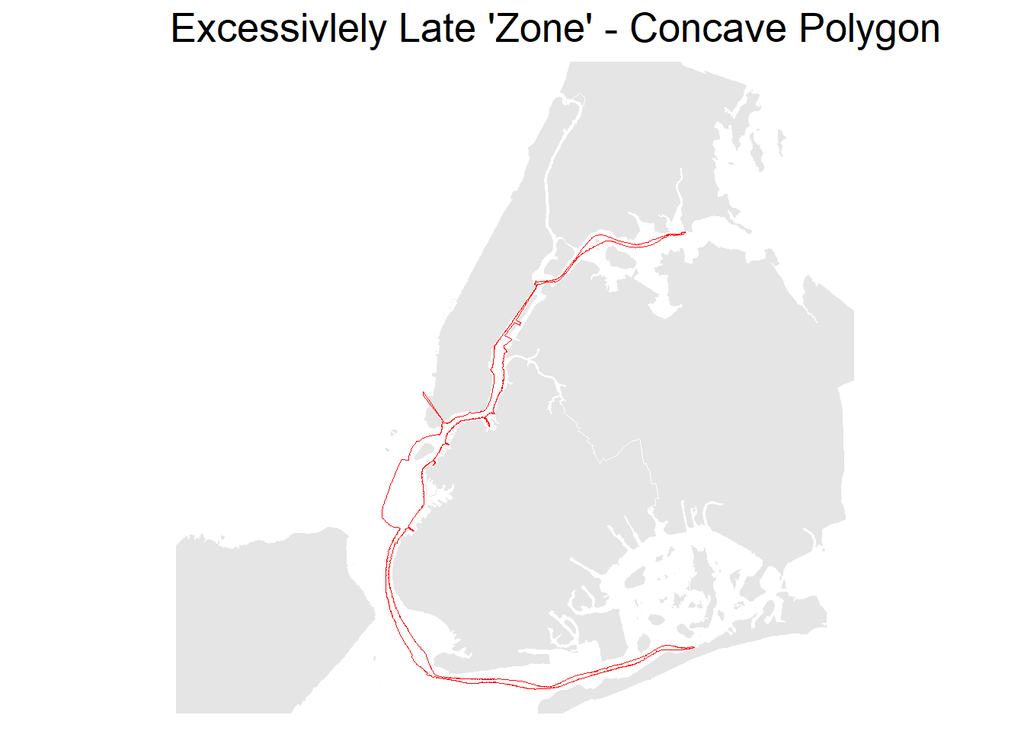

```r
jun2025_reference_week_excessively_lates <- jun2025_reference_week %>%
  filter(OTP == "Excessively Late")

jun2025_reference_week_excessively_lates_sf <- st_as_sf(jun2025_reference_week_excessively_lates, coords = c("lon", "lat"), crs = 4326, remove = FALSE) %>%
  st_transform(32118)

# Creates a boundary surrounding all data points that are considered excessively late
hull <- concaveman(jun2025_reference_week_excessively_lates_sf)

bbox_hull <- st_bbox(hull)

ggplot()+
  geom_sf(data = boroughs, color = "white") +
  geom_sf(data = hull, color = "red", fill = NA, size = 3) +
 # geom_sf(data = jun2025_reference_week_sf, aes(fill = OTP_transition, color = "red", size = 10, linewidth = 2)) +
 # geom_sf(data = jun2025_reference_week_excessively_lates_sf, color = "blue", size = 1) +
  coord_sf(
    xlim = c(bbox_east_river["xmin"] - 10000, bbox_east_river["xmax"]+ 10000),
    ylim = c(bbox_east_river["ymin"] - 10000, bbox_east_river["ymax"] + 10000),
    expand = FALSE
  ) +
   labs(
    title = "Excessivlely Late 'Zone' - Concave Polygon"
  ) +
  theme_solid() +
  theme(
    plot.title = element_text(size = 20),
    plot.title.position = "plot"
  )
```

```r
# Counts the number of data points per route
jun2025_reference_week %>%
  count(routeId)
```

```
## # A tibble: 7 × 2
##   routeId      n
##   <chr>    <int>
## 1 AS      121703
## 2 ER      189153
## 3 GI        9921
## 4 RW      152398
## 5 SB      129553
## 6 SG      118302
## 7 SV      130208
```

## OTP by Direction

This chunk computes the on-time performance of each data point by direction (NB or SB) and filters to only include those which are identified as excessively late and counts them. The first table shows OTP by direction across all routes, while the second table includes routes as an additioanlly category. Northbound and southbound trips comrpise roughly the same share of all trips; however, the higher number of excesively late southbound data points could be indicative of other issues.

```r
jun2025_reference_week_dir <- jun2025_reference_week %>%
  select(dailyTrip, directionId, OTP, routeId) %>%
  filter(OTP == "Excessively Late")

jun2025_reference_week_dir %>%
  count(directionId)
```

```
## # A tibble: 2 × 2
##   directionId     n
##   <chr>       <int>
## 1 NB          12069
## 2 SB          13488
```

```r
jun2025_reference_week_dir %>%
  count(directionId, routeId)
```

```
## # A tibble: 12 × 3
##    directionId routeId     n
##    <chr>       <chr>   <int>
##  1 NB          AS         51
##  2 NB          ER       2182
##  3 NB          GI         58
##  4 NB          RW       8300
##  5 NB          SB        671
##  6 NB          SG          5
##  7 NB          SV        802
##  8 SB          AS        472
##  9 SB          ER       4569
## 10 SB          RW       6040
## 11 SB          SB        696
## 12 SB          SV       1711
```

## Bar Charts

The following bar charts visualize some fo the existing and engineered features. The first chart shows the distribution of excessively late trips (i.e., any trip containing at least one data point identified as excessively late) by the “time” spent excessively late. A note here is that “time” in this context represents that count of data points considered excessively late, and the plot shows these counts as percentages of the total number of data points for trips.

```r
excessivelyLatePlotVariables <-
  jun2025_reference_week %>%
  as.data.frame() %>%
  select(excessivelyLate, dayOfWeek, routeId, timeOfDay, blockId, directionId, firstRecordLate) %>%
  gather(variable, value, -excessivelyLate) %>%
  filter(!is.na(value))

# Replace with dailyTrip for original
jun2025_reference_week_wide <- jun2025_reference_week %>%
  count(key_identifier, OTP) %>%
  pivot_wider(
    names_from = OTP,
    values_from = n,
    values_fill = 0,
  ) %>% mutate(Total = rowSums(across(-key_identifier)))


jun2025_reference_week_wide
```

```
## # A tibble: 2,133 × 6
##    key_identifier                   Early Ontime  Late `Excessively Late` Total
##    <chr>                            <int>  <int> <int>              <int> <dbl>
##  1 2025-06-16 11 ER 1220 NB Weekday    72    129     0                  0   201
##  2 2025-06-16 11 ER 1224 NB Weekday   191    189     0                  0   380
##  3 2025-06-16 11 ER 1257 SB Weekday   260    210    28                  0   498
##  4 2025-06-16 11 ER 4104 NB Weekday    86    309     0                  0   395
##  5 2025-06-16 11 ER 4109 NB Weekday    24    223     0                  0   247
##  6 2025-06-16 11 ER 4113 NB Weekday    52    330     0                  0   382
##  7 2025-06-16 11 ER 4116 NB Weekday    19    265    25                  0   309
##  8 2025-06-16 11 ER 4119 NB Weekday    85    217     0                  0   302
##  9 2025-06-16 11 ER 4123 NB Weekday     0    116   166                 24   306
## 10 2025-06-16 11 ER 4128 NB Weekday     0     32    30                293   355
## # ℹ 2,123 more rows
```

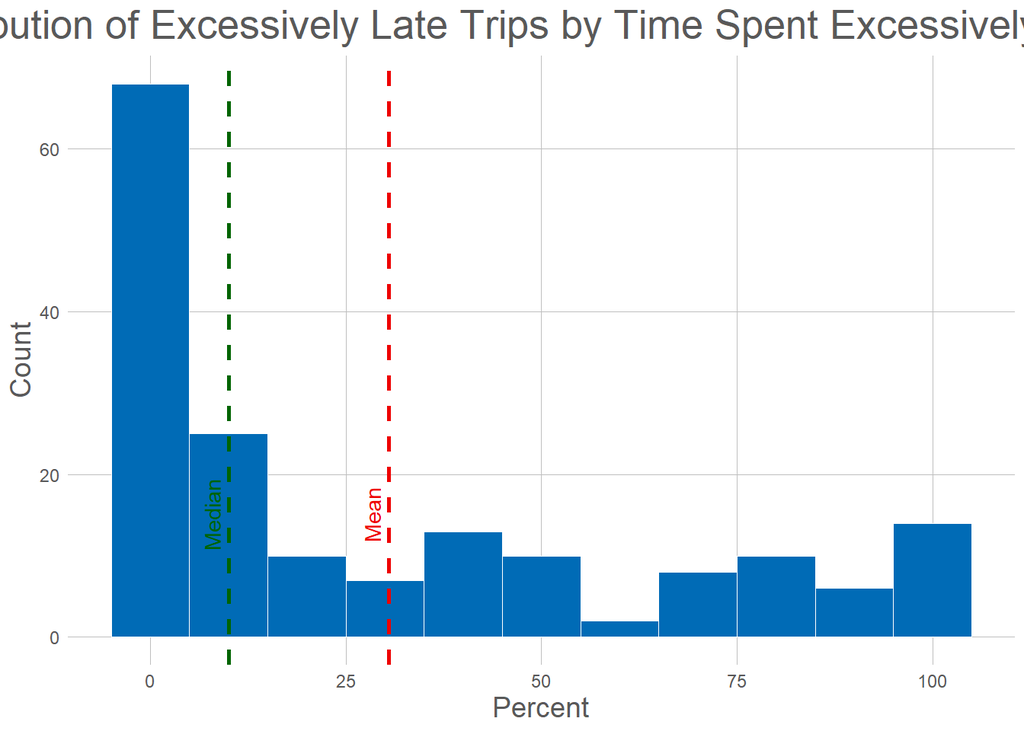

```r
jun2025_reference_week_percents <- jun2025_reference_week_wide %>%
  mutate(round(across(-c(key_identifier, Total),
                ~ . / Total * 100), 2)) %>%
  pivot_longer(
    cols = -c(key_identifier, Total),
    names_to = "OTP",
    values_to = "Percent"
  ) %>%  filter(OTP == "Excessively Late", Percent > 0) %>%
  mutate(Percent_Rounded = round(Percent, 0))


mean_val <- mean(jun2025_reference_week_percents$Percent_Rounded)
median_val <- median(jun2025_reference_week_percents$Percent_Rounded)

ggplot() +
  geom_histogram(data = jun2025_reference_week_percents, color = "white", fill = "#006bb6", linewidth = 0.3, aes(x = Percent_Rounded), binwidth = 10) +
  geom_vline(xintercept = mean_val, color = "red2",linetype = "dashed", linewidth = 1) +
  geom_vline(xintercept = median_val, color = "darkgreen",linetype = "dashed", linewidth = 1) +
  annotate("text", x = mean_val, y = 15, label = "Mean", color = "red2", angle = 90, vjust = -0.5) +
  annotate("text", x = median_val, y = 15, label = "Median", color = "darkgreen", angle = 90, vjust = -0.5) +
 # geom_bar(data = jun2025_reference_week_percents, color = "#828282", fill = "#006bb6", linewidth = 0.3, aes(x = Percent_Rounded)) +
  labs(
    title = "Distribution of Excessively Late Trips by Time Spent Excessively Late",
    x = "Percent",
    y = "Count"
  )+
  theme_excel_new() +
  theme(
    axis.title = element_text(size = 14),
    plot.title = element_text(size = 20),
    plot.subtitle = element_text(size = 16),
    plot.title.position = "plot"
  )
```

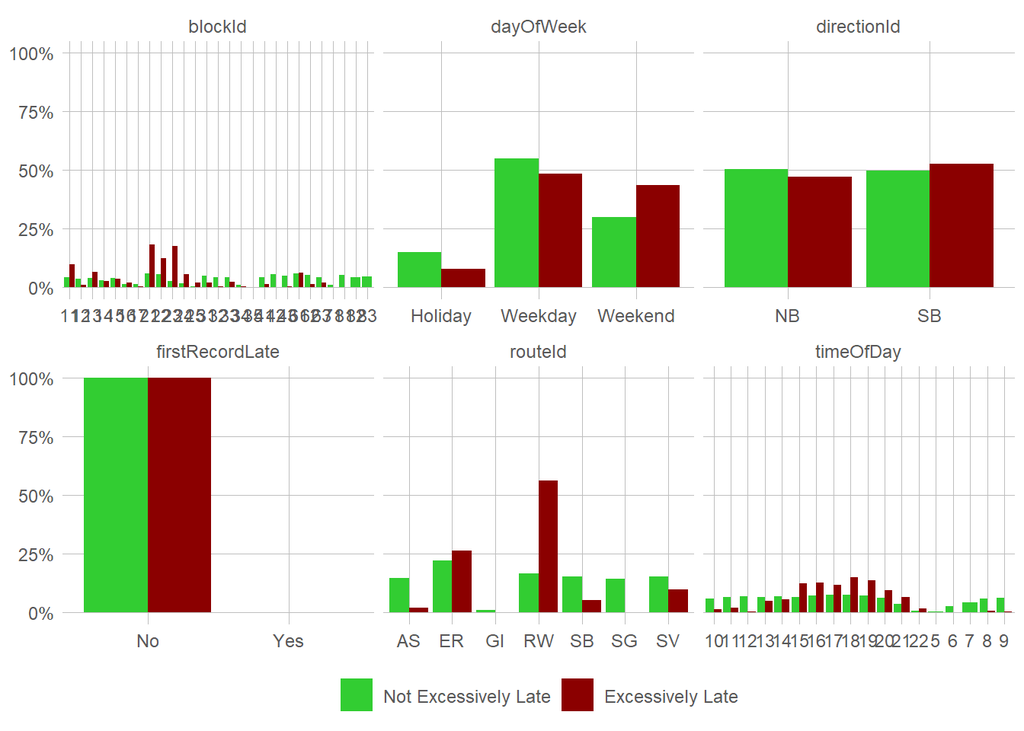

```r
plot_df <- excessivelyLatePlotVariables %>%
  group_by(excessivelyLate, variable, value) %>%
  summarise(count = n(), .groups = "drop") %>%
  group_by(excessivelyLate, variable) %>%
  mutate(prop = count / sum(count)) %>%
  ungroup()

ggplot(plot_df, aes(x = ifelse(variable == "timeOfDay",
                               as.numeric(value),
                               value), y = prop, fill = as.factor(excessivelyLate))) +
  geom_col(position = "dodge") +
  facet_wrap(~ variable, scales = "free_x") +
  scale_y_continuous(labels = scales::percent) +
  scale_fill_manual(values = c("0" = "limegreen", "1" = "darkred"),
                    labels = c("Not Excessively Late","Excessively Late"),
                    name = "") +
  labs(x = NULL, y = "Percent within group") +
  theme_excel_new()
```

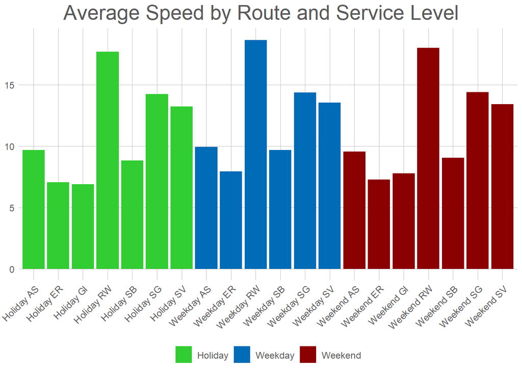

```r
jun2025_reference_week <- jun2025_reference_week %>%
  mutate(day_route = paste(dayOfWeek, routeId, sep = " "))

speed_by_route <- jun2025_reference_week %>%
  group_by(day_route, dayOfWeek, routeId) %>%
  summarise(
    avgKnots = mean(knots, na.rm = TRUE),
    medKnots = median(knots, na.rm = TRUE),
    n = dplyr::n(),
    .groups = "drop"
  )

ggplot() +
  geom_col(data = speed_by_route, aes(x = day_route, y = avgKnots, fill = dayOfWeek)) +
  labs(
    title = "Average Speed by Route and Service Level",
    x = "Service Level Month",
    y = "Average Knots"
  ) +
  scale_fill_manual(
    values = c(
      "Holiday" = "limegreen",
      "Weekday" = "#006bb6",
      "Weekend" = "darkred"
    )
  ) +
  theme_excel_new()  +
  theme(
    plot.title = element_text(size = 20),
    plot.subtitle = element_text(size = 16),
    plot.title.position = "plot",
    axis.text.x = element_text(angle = 45, hjust = 1)
  )
```

## Data Based on Identifier

```r
jun2025_reference_week_summary <- jun2025_reference_week %>%
  group_by(date_route_trip_direction_vehicle_dow) %>%
  summarise(
    trip_minutes = as.integer(
      difftime(max(date_time), min(date_time), units = "mins")
    ),
    .groups = "drop"
  )
```

## Plots

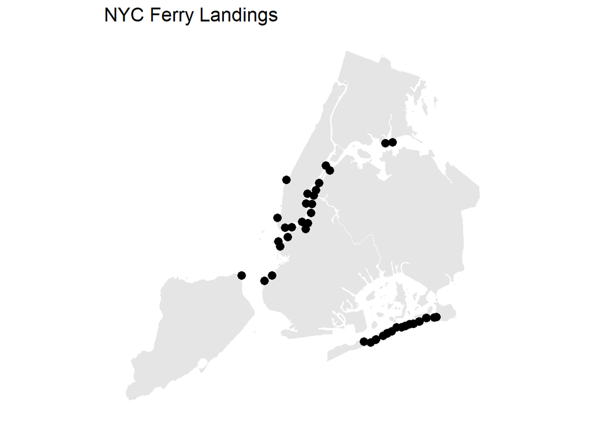

```r
ggplot()+
  geom_sf(data = boroughs, color = "white") +
  geom_sf(data = landings, color = "black", size = 3) +
   labs(
    title = "NYC Ferry Landings"
  ) +
  theme_solid() +
  theme(
    plot.title = element_text(size = 16),
    plot.title.position = "plot"
  )
```

## Fishnet

Since these datasets contain thousands of points per day, aggregation is the most efficient way to process and observe the data. Thus, a fishnet was created using a grid cell side of 250 meters. The figure represents the data for the sample week, excluding any grid cell with a density of 0.

```r
nrow(water)
```

```
## [1] 1
```

```r
st_crs(water)
```

```
## Coordinate Reference System:
##   User input: EPSG:32118
##   wkt:
## PROJCRS["NAD83 / New York Long Island",
##     BASEGEOGCRS["NAD83",
##         DATUM["North American Datum 1983",
##             ELLIPSOID["GRS 1980",6378137,298.257222101,
##                 LENGTHUNIT["metre",1]]],
##         PRIMEM["Greenwich",0,
##             ANGLEUNIT["degree",0.0174532925199433]],
##         ID["EPSG",4269]],
##     CONVERSION["SPCS83 New York Long Island zone (meter)",
##         METHOD["Lambert Conic Conformal (2SP)",
##             ID["EPSG",9802]],
##         PARAMETER["Latitude of false origin",40.1666666666667,
##             ANGLEUNIT["degree",0.0174532925199433],
##             ID["EPSG",8821]],
##         PARAMETER["Longitude of false origin",-74,
##             ANGLEUNIT["degree",0.0174532925199433],
##             ID["EPSG",8822]],
##         PARAMETER["Latitude of 1st standard parallel",41.0333333333333,
##             ANGLEUNIT["degree",0.0174532925199433],
##             ID["EPSG",8823]],
##         PARAMETER["Latitude of 2nd standard parallel",40.6666666666667,
##             ANGLEUNIT["degree",0.0174532925199433],
##             ID["EPSG",8824]],
##         PARAMETER["Easting at false origin",300000,
##             LENGTHUNIT["metre",1],
##             ID["EPSG",8826]],
##         PARAMETER["Northing at false origin",0,
##             LENGTHUNIT["metre",1],
##             ID["EPSG",8827]]],
##     CS[Cartesian,2],
##         AXIS["easting (X)",east,
##             ORDER[1],
##             LENGTHUNIT["metre",1]],
##         AXIS["northing (Y)",north,
##             ORDER[2],
##             LENGTHUNIT["metre",1]],
##     USAGE[
##         SCOPE["Engineering survey, topographic mapping."],
##         AREA["United States (USA) - New York - counties of Bronx; Kings; Nassau; New York; Queens; Richmond; Suffolk."],
##         BBOX[40.47,-74.26,41.3,-71.8]],
##     ID["EPSG",32118]]
```

```r
st_bbox(water)
```

```
##      xmin      ymin      xmax      ymax
## 278721.27  37546.47 328728.47  85947.78
```

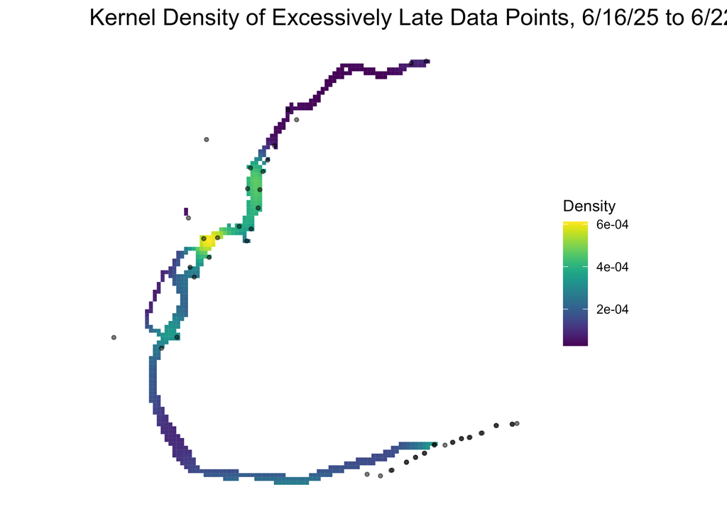

```r
fishnet <-
  st_make_grid(water, cellsize = 250) %>%
  st_sf() %>%
  mutate(uniqueID = rownames(.))

jun2025_net <- st_join(
  fishnet, jun2025_reference_week_excessively_lates_sf, join = st_intersects) %>%
  group_by(uniqueID) %>%
  summarise(mean_speed = mean(knots, na.rm=TRUE),
            n = n(), .groups="drop",
) %>%
  filter(!is.na(mean_speed))

jun2025_ppp <- as.ppp(st_coordinates(jun2025_reference_week_excessively_lates_sf), W = st_bbox(jun2025_net))
jun2025_KD <- density.ppp(jun2025_ppp, sigma = 1000)


as.data.frame(jun2025_KD) %>%
  st_as_sf(coords = c("x", "y"), crs = st_crs(jun2025_net)) %>%
  aggregate(., jun2025_net, mean) %>%
   ggplot() +
     geom_sf(aes(fill=value), color = NA, linewidth=0) +
     geom_sf(data = landings, color = "black", size = 1, alpha = 0.5) +
     scale_fill_viridis(name = "Density") +
     labs(title = "Kernel Density of Excessively Late Data Points, 6/16/25 to 6/22/25") +
     theme_solid() +
  theme(
    plot.title = element_text(size = 16),
    plot.subtitle = element_text(size = 16),
    plot.title.position = "plot")
```

## Mean Speed

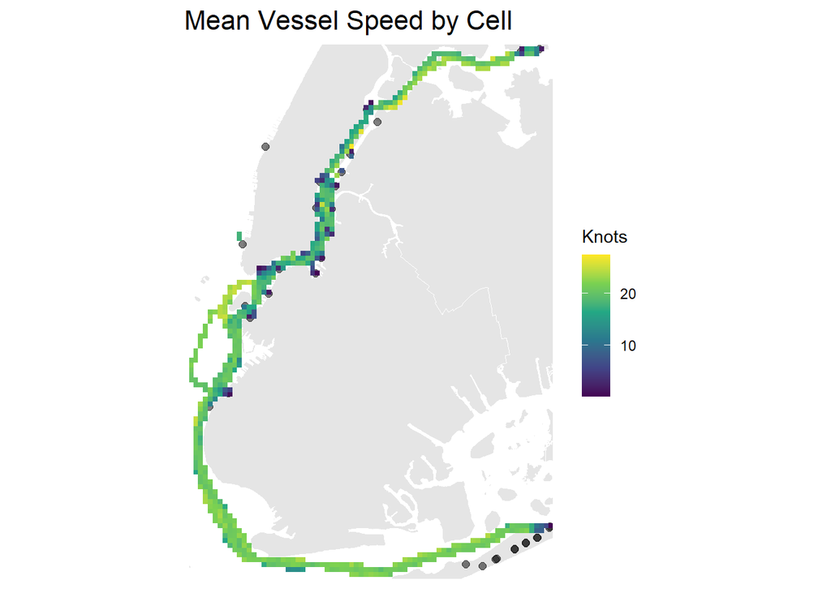

```r
ggplot(jun2025_net) +
  geom_sf(data = boroughs, color = "white") +
  geom_sf(data = landings, color = "black", size = 2, alpha = 0.5) +
  geom_sf(aes(fill = mean_speed), color = NA) +
    coord_sf(
      xlim = c(bbox_hull["xmin"] - 100, bbox_hull["xmax"] + 100),
      ylim = c(bbox_hull["ymin"] - 200, bbox_hull["ymax"] + 200),
      expand = FALSE
    ) +
  scale_fill_viridis_c(option = "D", name = "Knots") +
  labs(
    title = "Mean Vessel Speed by Cell"
  ) +
  theme_solid() +
  theme(
    plot.title = element_text(size = 16),
    plot.subtitle = element_text(size = 16),
    plot.title.position = "plot")
```

## Kernel Density Plots - Hourly

To analyze how OTP changes spatially throughout the PM peak times, the kernel densities of excessively late data points were mapped for each hour between 1pm and 10pm (inclusive).

```r
jun2025_net_13 <- st_join(
  fishnet, jun2025_reference_week_excessively_lates_sf, join = st_intersects) %>%
  group_by(uniqueID) %>%
  filter(hour == "13") %>%
  summarise(mean_speed = mean(knots, na.rm=TRUE),
            n = n(), .groups="drop",)
jun2025_net_13_ppp <- as.ppp(st_coordinates(jun2025_net_13), W = st_bbox(jun2025_net))
jun2025_net_13_KD <- density.ppp(jun2025_net_13_ppp, sigma = 1000)

jun2025_net_14 <- st_join(
  fishnet, jun2025_reference_week_excessively_lates_sf, join = st_intersects) %>%
  group_by(uniqueID) %>%
  filter(hour == "14") %>%
  summarise(mean_speed = mean(knots, na.rm=TRUE),
            n = n(), .groups="drop",)
jun2025_net_14_ppp <- as.ppp(st_coordinates(jun2025_net_14), W = st_bbox(jun2025_net))
jun2025_net_14_KD <- density.ppp(jun2025_net_14_ppp, sigma = 1000)

jun2025_net_15 <- st_join(
  fishnet, jun2025_reference_week_excessively_lates_sf, join = st_intersects) %>%
  group_by(uniqueID) %>%
  filter(hour == "15") %>%
  summarise(mean_speed = mean(knots, na.rm=TRUE),
            n = n(), .groups="drop",)
jun2025_net_15_ppp <- as.ppp(st_coordinates(jun2025_net_15), W = st_bbox(jun2025_net))
jun2025_net_15_KD <- density.ppp(jun2025_net_15_ppp, sigma = 1000)

jun2025_net_16 <- st_join(
  fishnet, jun2025_reference_week_excessively_lates_sf, join = st_intersects) %>%
  group_by(uniqueID) %>%
  filter(hour == "16") %>%
  summarise(mean_speed = mean(knots, na.rm=TRUE),
            n = n(), .groups="drop",)
jun2025_net_16_ppp <- as.ppp(st_coordinates(jun2025_net_16), W = st_bbox(jun2025_net))
jun2025_net_16_KD <- density.ppp(jun2025_net_16_ppp, sigma = 1000)

jun2025_net_17 <- st_join(
  fishnet, jun2025_reference_week_excessively_lates_sf, join = st_intersects) %>%
  group_by(uniqueID) %>%
  filter(hour == "17") %>%
  summarise(mean_speed = mean(knots, na.rm=TRUE),
            n = n(), .groups="drop",)
jun2025_net_17_ppp <- as.ppp(st_coordinates(jun2025_net_17), W = st_bbox(jun2025_net))
jun2025_net_17_KD <- density.ppp(jun2025_net_17_ppp, sigma = 1000)

jun2025_net_18 <- st_join(
  fishnet, jun2025_reference_week_excessively_lates_sf, join = st_intersects) %>%
  group_by(uniqueID) %>%
  filter(hour == "18") %>%
  summarise(mean_speed = mean(knots, na.rm=TRUE),
            n = n(), .groups="drop",)
jun2025_net_18_ppp <- as.ppp(st_coordinates(jun2025_net_18), W = st_bbox(jun2025_net))
jun2025_net_18_KD <- density.ppp(jun2025_net_18_ppp, sigma = 1000)

jun2025_net_19 <- st_join(
  fishnet, jun2025_reference_week_excessively_lates_sf, join = st_intersects) %>%
  group_by(uniqueID) %>%
  filter(hour == "19") %>%
  summarise(mean_speed = mean(knots, na.rm=TRUE),
            n = n(), .groups="drop",)
jun2025_net_19_ppp <- as.ppp(st_coordinates(jun2025_net_19), W = st_bbox(jun2025_net))
jun2025_net_19_KD <- density.ppp(jun2025_net_19_ppp, sigma = 1000)

jun2025_net_20 <- st_join(
  fishnet, jun2025_reference_week_excessively_lates_sf, join = st_intersects) %>%
  group_by(uniqueID) %>%
  filter(hour == "20") %>%
  summarise(mean_speed = mean(knots, na.rm=TRUE),
            n = n(), .groups="drop",)
jun2025_net_20_ppp <- as.ppp(st_coordinates(jun2025_net_20), W = st_bbox(jun2025_net))
jun2025_net_20_KD <- density.ppp(jun2025_net_20_ppp, sigma = 1000)

jun2025_net_21 <- st_join(
  fishnet, jun2025_reference_week_excessively_lates_sf, join = st_intersects) %>%
  group_by(uniqueID) %>%
  filter(hour == "21") %>%
  summarise(mean_speed = mean(knots, na.rm=TRUE),
            n = n(), .groups="drop",)
jun2025_net_21_ppp <- as.ppp(st_coordinates(jun2025_net_21), W = st_bbox(jun2025_net))
jun2025_net_21_KD <- density.ppp(jun2025_net_21_ppp, sigma = 1000)

jun2025_net_22 <- st_join(
  fishnet, jun2025_reference_week_excessively_lates_sf, join = st_intersects) %>%
  group_by(uniqueID) %>%
  filter(hour == "22") %>%
  summarise(mean_speed = mean(knots, na.rm=TRUE),
            n = n(), .groups="drop",)
jun2025_net_22_ppp <- as.ppp(st_coordinates(jun2025_net_22), W = st_bbox(jun2025_net))
jun2025_net_22_KD <- density.ppp(jun2025_net_22_ppp, sigma = 1000)
```

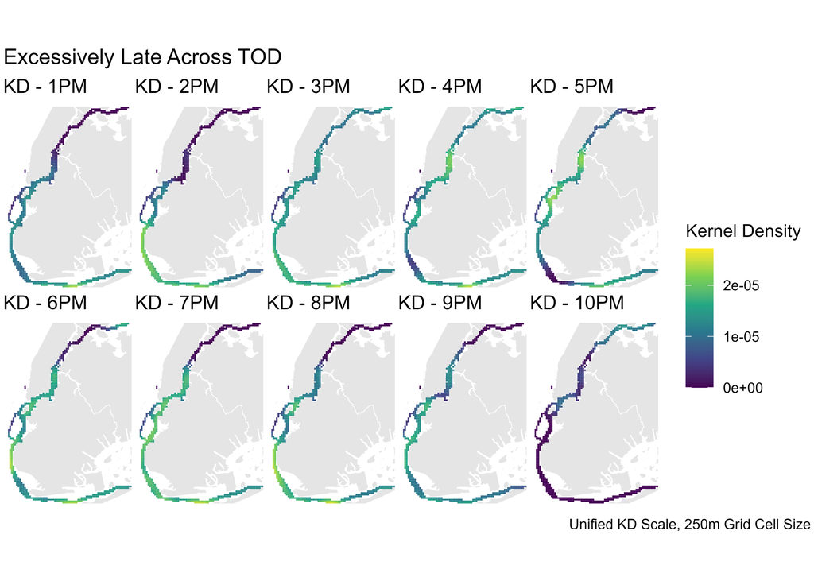

```r
plot13 <- as.data.frame(jun2025_net_13_KD) %>%
  st_as_sf(coords = c("x", "y"), crs = st_crs(jun2025_net_13)) %>%
  aggregate(., jun2025_net_13, mean) %>%
  ggplot() +
    geom_sf(data = boroughs, color = "white") +
  geom_sf(aes(fill = value), color = NA, linewidth = 0) +
#  geom_sf(data = landings, color = "black", size = 1, alpha = 0.5) +
  coord_sf(
    xlim = c(bbox_hull["xmin"] -100, bbox_hull["xmax"] +100),
    ylim = c(bbox_hull["ymin"] -100, bbox_hull["ymax"] +100),
    expand = FALSE
  ) +
  scale_fill_viridis_c(name = "") +
  scale_color_discrete(name = "Route") +
  labs(title = "Kernel Density - 1:00PM") +
  theme_solid() +
  theme(
    plot.title = element_text(size = 16),
    plot.subtitle = element_text(size = 16),
    plot.title.position = "plot"
  )

plot14 <- as.data.frame(jun2025_net_14_KD) %>%
  st_as_sf(coords = c("x", "y"), crs = st_crs(jun2025_net_14)) %>%
  aggregate(., jun2025_net_14, mean) %>%
  ggplot() +
    geom_sf(data = boroughs, color = "white") +
  geom_sf(aes(fill = value), color = NA, linewidth = 0) +
#  geom_sf(data = landings, color = "black", size = 1, alpha = 0.5) +
  coord_sf(
    xlim = c(bbox_hull["xmin"] -100, bbox_hull["xmax"] +100),
    ylim = c(bbox_hull["ymin"] -100, bbox_hull["ymax"] +100),
    expand = FALSE
  ) +
  scale_fill_viridis_c(name = "") +
  scale_color_discrete(name = "Route") +
  labs(title = "Kernel Density - 2:00PM") +
  theme_solid() +
  theme(
    plot.title = element_text(size = 16),
    plot.subtitle = element_text(size = 16),
    plot.title.position = "plot"
  )

plot15 <- as.data.frame(jun2025_net_15_KD) %>%
  st_as_sf(coords = c("x", "y"), crs = st_crs(jun2025_net_15)) %>%
  aggregate(., jun2025_net_15, mean) %>%
  ggplot() +
    geom_sf(data = boroughs, color = "white") +
  geom_sf(aes(fill = value), color = NA, linewidth = 0) +
#  geom_sf(data = landings, color = "black", size = 1, alpha = 0.5) +
  coord_sf(
    xlim = c(bbox_hull["xmin"] -100, bbox_hull["xmax"] +100),
    ylim = c(bbox_hull["ymin"] -100, bbox_hull["ymax"] +100),
    expand = FALSE
  ) +
  scale_fill_viridis_c(name = "") +
  scale_color_discrete(name = "Route") +
  labs(title = "Kernel Density - 3:00PM") +
  theme_solid() +
  theme(
    plot.title = element_text(size = 16),
    plot.subtitle = element_text(size = 16),
    plot.title.position = "plot"
  )

plot16 <- as.data.frame(jun2025_net_16_KD) %>%
  st_as_sf(coords = c("x", "y"), crs = st_crs(jun2025_net_16)) %>%
  aggregate(., jun2025_net_16, mean) %>%
  ggplot() +
    geom_sf(data = boroughs, color = "white") +
  geom_sf(aes(fill = value), color = NA, linewidth = 0) +
#  geom_sf(data = landings, color = "black", size = 1, alpha = 0.5) +
  coord_sf(
    xlim = c(bbox_hull["xmin"] -100, bbox_hull["xmax"] +100),
    ylim = c(bbox_hull["ymin"] -100, bbox_hull["ymax"] +100),
    expand = FALSE
  ) +
  scale_fill_viridis_c(name = "") +
  scale_color_discrete(name = "Route") +
  labs(title = "Kernel Density - 4:00PM") +
  theme_solid() +
  theme(
    plot.title = element_text(size = 16),
    plot.subtitle = element_text(size = 16),
    plot.title.position = "plot"
  )

plot17 <- as.data.frame(jun2025_net_17_KD) %>%
  st_as_sf(coords = c("x", "y"), crs = st_crs(jun2025_net_17)) %>%
  aggregate(., jun2025_net_17, mean) %>%
  ggplot() +
    geom_sf(data = boroughs, color = "white") +
  geom_sf(aes(fill = value), color = NA, linewidth = 0) +
#  geom_sf(data = landings, color = "black", size = 1, alpha = 0.5) +
  coord_sf(
    xlim = c(bbox_hull["xmin"] -100, bbox_hull["xmax"] +100),
    ylim = c(bbox_hull["ymin"] -100, bbox_hull["ymax"] +100),
    expand = FALSE
  ) +
  scale_fill_viridis_c(name = "") +
  scale_color_discrete(name = "Route") +
  labs(title = "Kernel Density - 5:00PM") +
  theme_solid() +
  theme(
    plot.title = element_text(size = 16),
    plot.subtitle = element_text(size = 16),
    plot.title.position = "plot"
  )

plot18 <- as.data.frame(jun2025_net_18_KD) %>%
  st_as_sf(coords = c("x", "y"), crs = st_crs(jun2025_net_18)) %>%
  aggregate(., jun2025_net_18, mean) %>%
  ggplot() +
    geom_sf(data = boroughs, color = "white") +
  geom_sf(aes(fill = value), color = NA, linewidth = 0) +
#  geom_sf(data = landings, color = "black", size = 1, alpha = 0.5) +
  coord_sf(
    xlim = c(bbox_hull["xmin"] -100, bbox_hull["xmax"] +100),
    ylim = c(bbox_hull["ymin"] -100, bbox_hull["ymax"] +100),
    expand = FALSE
  ) +
  scale_fill_viridis_c(name = "") +
  scale_color_discrete(name = "Route") +
  labs(title = "Kernel Density - 6:00PM") +
  theme_solid() +
  theme(
    plot.title = element_text(size = 16),
    plot.subtitle = element_text(size = 16),
    plot.title.position = "plot"
  )

plot19 <- as.data.frame(jun2025_net_19_KD) %>%
  st_as_sf(coords = c("x", "y"), crs = st_crs(jun2025_net_19)) %>%
  aggregate(., jun2025_net_19, mean) %>%
  ggplot() +
    geom_sf(data = boroughs, color = "white") +
  geom_sf(aes(fill = value), color = NA, linewidth = 0) +
#  geom_sf(data = landings, color = "black", size = 1, alpha = 0.5) +
  coord_sf(
    xlim = c(bbox_hull["xmin"] -100, bbox_hull["xmax"] +100),
    ylim = c(bbox_hull["ymin"] -100, bbox_hull["ymax"] +100),
    expand = FALSE
  ) +
  scale_fill_viridis_c(name = "") +
  scale_color_discrete(name = "Route") +
  labs(title = "Kernel Density - 7:00PM") +
  theme_solid() +
  theme(
    plot.title = element_text(size = 16),
    plot.subtitle = element_text(size = 16),
    plot.title.position = "plot"
  )

plot20 <- as.data.frame(jun2025_net_20_KD) %>%
  st_as_sf(coords = c("x", "y"), crs = st_crs(jun2025_net_20)) %>%
  aggregate(., jun2025_net_20, mean) %>%
  ggplot() +
    geom_sf(data = boroughs, color = "white") +
  geom_sf(aes(fill = value), color = NA, linewidth = 0) +
#  geom_sf(data = landings, color = "black", size = 1, alpha = 0.5) +
  coord_sf(
    xlim = c(bbox_hull["xmin"] -100, bbox_hull["xmax"] +100),
    ylim = c(bbox_hull["ymin"] -100, bbox_hull["ymax"] +100),
    expand = FALSE
  ) +
  scale_fill_viridis_c(name = "") +
  scale_color_discrete(name = "Route") +
  labs(title = "Kernel Density - 8:00PM") +
  theme_solid() +
  theme(
    plot.title = element_text(size = 16),
    plot.subtitle = element_text(size = 16),
    plot.title.position = "plot"
  )

plot21 <- as.data.frame(jun2025_net_21_KD) %>%
  st_as_sf(coords = c("x", "y"), crs = st_crs(jun2025_net_21)) %>%
  aggregate(., jun2025_net_21, mean) %>%
  ggplot() +
    geom_sf(data = boroughs, color = "white") +
  geom_sf(aes(fill = value), color = NA, linewidth = 0) +
#  geom_sf(data = landings, color = "black", size = 1, alpha = 0.5) +
  coord_sf(
    xlim = c(bbox_hull["xmin"] -100, bbox_hull["xmax"] +100),
    ylim = c(bbox_hull["ymin"] -100, bbox_hull["ymax"] +100),
    expand = FALSE
  ) +
  scale_fill_viridis_c(name = "") +
  scale_color_discrete(name = "Route") +
  labs(title = "Kernel Density - 9:00PM") +
  theme_solid() +
  theme(
    plot.title = element_text(size = 16),
    plot.subtitle = element_text(size = 16),
    plot.title.position = "plot"
  )

plot22 <- as.data.frame(jun2025_net_22_KD) %>%
  st_as_sf(coords = c("x", "y"), crs = st_crs(jun2025_net_22)) %>%
  aggregate(., jun2025_net_22, mean) %>%
  ggplot() +
    geom_sf(data = boroughs, color = "white") +
  geom_sf(aes(fill = value), color = NA, linewidth = 0) +
#  geom_sf(data = landings, color = "black", size = 1, alpha = 0.5) +
  coord_sf(
    xlim = c(bbox_hull["xmin"] -100, bbox_hull["xmax"] +100),
    ylim = c(bbox_hull["ymin"] -100, bbox_hull["ymax"] +100),
    expand = FALSE
  ) +
  scale_fill_viridis_c(name = "") +
  scale_color_discrete(name = "Route") +
  labs(title = "Kernel Density - 9:00PM") +
  theme_solid() +
  theme(
    plot.title = element_text(size = 16),
    plot.subtitle = element_text(size = 16),
    plot.title.position = "plot"
  )

plots <- list(plot13,
              plot14,
              plot15,
              plot16,
              plot17,
              plot18,
              plot19,
              plot20,
              plot21,
              plot22
)

# Actual Plot

kd_list <- list(
  '1PM' = jun2025_net_13_KD,
  '2PM' = jun2025_net_14_KD,
  '3PM' = jun2025_net_15_KD,
  '4PM' = jun2025_net_16_KD,
  '5PM' = jun2025_net_17_KD,
  '6PM' = jun2025_net_18_KD,
  '7PM' = jun2025_net_19_KD,
  '8PM' = jun2025_net_20_KD,
  '9PM' = jun2025_net_21_KD,
  '10PM' = jun2025_net_22_KD
)

all_values <- unlist(lapply(kd_list, \(kd) as.data.frame(kd)$value))
global_limits <- range(all_values, na.rm = TRUE)

plots <- imap(kd_list, ~{
  df <- as.data.frame(.x)  # columns: x, y, value

  sf_pts <- st_as_sf(df, coords = c("x","y"), crs = st_crs(jun2025_net))

  # aggregate ONLY the value column so the output column name stays clean
  agg <- aggregate(sf_pts["value"], jun2025_net, mean, na.rm = TRUE)

  ggplot() +
    geom_sf(data = boroughs, color = "white") +
    geom_sf(data = agg, aes(fill = value), color = NA, linewidth = 0) +
    coord_sf(
      xlim = c(bbox_hull["xmin"] - 100, bbox_hull["xmax"] + 100),
      ylim = c(bbox_hull["ymin"] - 100, bbox_hull["ymax"] + 100),
      expand = FALSE
    ) +
    scale_fill_viridis_c(
      name = "Kernel Density",
      limits = global_limits,
      oob = scales::squish
    ) +
    labs(title = paste("KD -", .y)) +
    theme_solid() +
  theme(
    plot.title = element_text(size = 12),
    plot.subtitle = element_text(size = 12),
    plot.caption = element_text(size = 12),
    plot.title.position = "plot"
  )
})

wrap_plots(plots, ncol = 5) +
  plot_layout(guides = "collect") +
  plot_annotation(
    title = "Excessively Late Across TOD",
    caption = "Unified KD Scale, 250m Grid Cell Size"
  ) &
  theme(
    legend.position = "right",
    legend.box = "horizontal",
    plot.margin = margin(1, 1, 1, 1)
  )
```

One potentially useful consideration in this analysis is to observe locations where trips change OTP status (e.g., on-time to late, late to excessively late). The following figure does exactly that, only including instances where the OTP status changes to either late or excessively late.

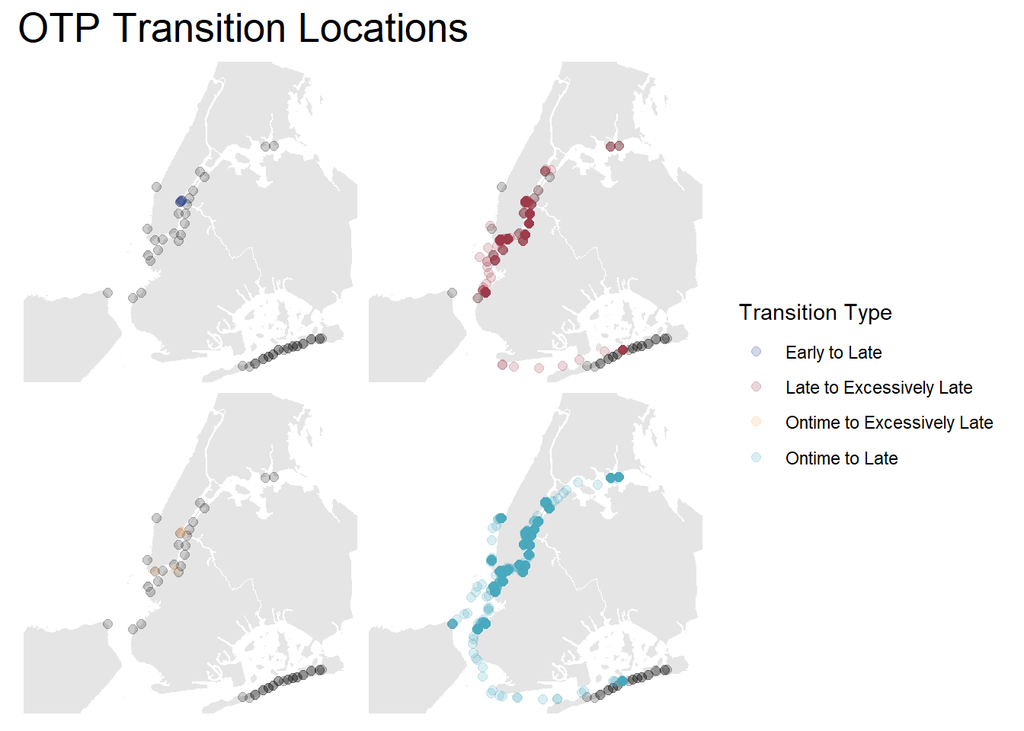

```r
jun2025_reference_week_late_sf <- jun2025_reference_week_sf %>%
  filter(OTP_transition %in% c("Early -> Late", "Late -> Excessively Late", "Ontime -> Late", "Ontime -> Excessively Late"
))

ggplot()+
  geom_sf(data = boroughs, color = "white") +
  geom_sf(data = landings, color = "black", size = 2, alpha = 0.2) +
  geom_sf(data = jun2025_reference_week_late_sf,
          aes(color = OTP_transition), size = 2, alpha = 0.2) +
  coord_sf(
    xlim = c(bbox_east_river["xmin"] - 10000, bbox_east_river["xmax"]+ 10000),
    ylim = c(bbox_east_river["ymin"] - 10000, bbox_east_river["ymax"] + 10000),
    expand = FALSE
  ) +
   labs(
    title = "OTP Transition Locations"
  ) +
  scale_color_manual(
    name = "Transition Type",
    values = c(
      "Early -> Late" = "#1e3888",
      "Ontime -> Late" = "#47a8bd",
      "Ontime -> Excessively Late" = "#ffad69",
      "Late -> Excessively Late" = "#9c3848"),
    labels = c(
      "Early -> Late" = "Early to Late",
      "Ontime -> Late" = "Ontime to Late",
      "Ontime -> Excessively Late" = "Ontime to Excessively Late",
      "Late -> Excessively Late" = "Late to Excessively Late"
    )
  ) +
  facet_wrap(~OTP_transition) +
  theme_solid() +
  theme(
    plot.title = element_text(size = 20),
    plot.title.position = "plot"
  )
```

## Leaflet Distribution of Data Points by Excessive Lateness

```r
landings_buffers_100ft <- st_buffer(landings, dist = 30.48)

counts <- lengths(st_intersects(landings_buffers_100ft, jun2025_reference_week_excessively_lates_sf))

landings_buffers_100ft$record_count <- counts

points_plot <- st_transform(landings, 4326)
buffers_plot <- st_transform(landings_buffers_100ft, 4326)
routes_plot <- st_transform(routes, 4326)
boroughs_plot <- st_transform(boroughs, 4326)

jun2025_reference_week_elate_sf <- jun2025_reference_week_sf %>%
  filter(OTP == "Excessively Late") %>%
  st_transform(4326)

jun2025_reference_week_not_elate_sf <- jun2025_reference_week_sf %>%
  filter(OTP != "Excessively Late") %>%
  st_transform(4326)

leaflet() %>%
  addProviderTiles("Esri.WorldImagery",
                   group = "Imagery",
                   options = tileOptions(opacity = 0.6)) %>%
  addPolygons(data = boroughs_plot, color = "#828282", weight = 1, fillOpacity = 0.75, group = "Boroughs") %>%
  addPolylines(data = routes_plot, color = "#006bb6", weight = 2, opacity = 0.2, group = "Routes") %>%
  addPolygons(data = buffers_plot, color = "#f58426", weight = 10, fillOpacity = 0.75, group = "Landings",
              label = ~paste0("Records: ", record_count)) %>%
  addCircleMarkers(data = points_plot, radius = 3, color = "#f58426", opacity = 0.6, group = "Landings") %>%
  addCircleMarkers(
    data = jun2025_reference_week_elate_sf, radius = 0.5, color = "#47a8bd",
    opacity = 0.6, fillOpacity = 0.4, group = "Not Excessively Late",
    label = ~paste0("Speed: ", round(knots, 2)),
    popup = ~paste0("<b>Speed:</b> ", round(knots, 2), " m/s",
                    "<br><b>Route:</b> ", routeId,
                    "<br><b>Trip:</b> ", tripId,
                    "<br><b>Vessel</b> ", vehicleId,
                    "<br><b>Time:</b> ", time)
  ) %>%
  addCircleMarkers(
    data = jun2025_reference_week_not_elate_sf, radius = 0.5, color = "#9c3848",
    opacity = 0.6, fillOpacity = 0.4, group = "Excessively Late",
    label = ~paste0("Speed: ", round(knots, 2)),
    popup = ~paste0("<b>Speed:</b> ", round(knots, 2), " m/s",
                    "<br><b>Route:</b> ", routeId,
                    "<br><b>Trip:</b> ", tripId,
                    "<br><b>Vessel</b> ", vehicleId,
                    "<br><b>Time:</b> ", time)
  ) %>%
  addLayersControl(
    overlayGroups = c("Boroughs", "Routes", "Landings", "Not Excessively Late", "Excessively Late"),
    baseGroups = c("Imagery"),
    options = layersControlOptions(collapsed = FALSE)
  ) %>%
  htmlwidgets::onRender("
    function(el, x) {
      var map = this;

      function logBounds() {
        var b = map.getBounds();
        console.log('bbox:',
          'xmin', b.getWest(),
          'ymin', b.getSouth(),
          'xmax', b.getEast(),
          'ymax', b.getNorth()
        );
      }

      map.whenReady(function() {
        logBounds();               // log once on load
        map.on('moveend', logBounds);
      });
    }
  ") %>%
  addControl(
    html = "<div class='map-title'>My Map Title</div>",
    position = "topleft"
  )
```

This Leaflet map shows the data with an imagery layer for context. For the sake of processing power, the results were not shown. However, the code is available and can be viewed by removing the “eval=FALSE” parameter at the beginning of this chunk.